# BNP-Step Parameter Sweep for testing

Using BNP-Step to analyze time-series data sets that are generated to show its superiority in cases of: different noise levels

This gives you a range to look for (from your data) the best parameter space to use, if it varies at all

## Basic usage

To get started, first import the BNPStep class:

```python
import bnpstep as bnp
```

Next, create a fresh BNPStep object.

```python
sampler = bnp.BNPStep()
```

To load a data set, first ensure your data set is in the same directory as the BNP-Step source files. Next, load your data set using the load_data() method. Currently, accepted formats are:

```
.txt, no time points, with each observation delimited by a newline (\n)
    Example: 62.6
             42.3
             53.4
             68.8
             ...

.txt with time points, with times first and observations second, separated by a comma (no space).
Each time, observation pair is delimited by a newline.
    Example: 1.0,62.6
             2.0,42.3
             3.0,53.4
             4.0,68.8
             ...

.csv, no time points. Observations can be as a single column or single row.

.csv with time points. Time points are in the first column, while observations are in the second column. There should be only one time, observation pair per row.
```

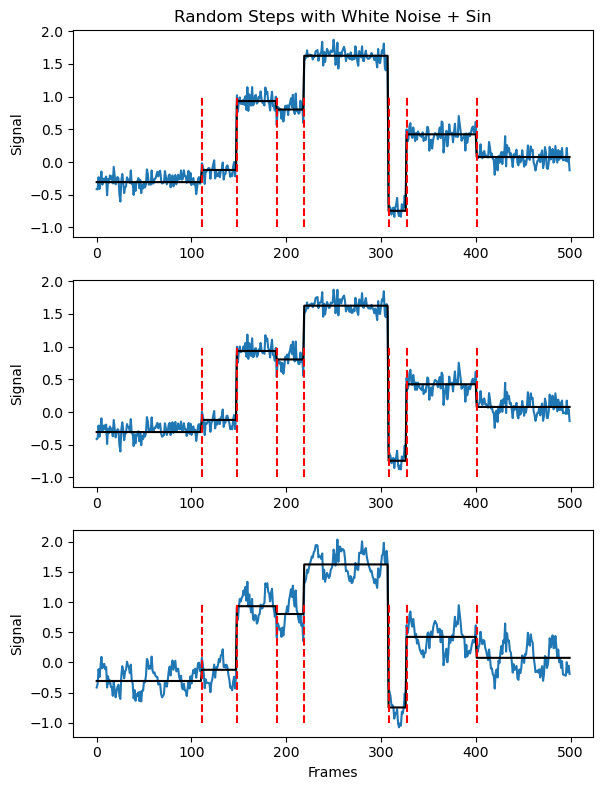

```python
# Generate data (chatGPT helped) that adds sources of noise.

# This script explicitly makes sinusoidal-esque noise

import numpy as np
import matplotlib.pyplot as plt
import pandas as pd
import time

randomseed = 1
np.random.seed(randomseed)  # for reproducibility

# Parameters
Anoise = [0.01, 0.05, 0.2]
saveroot = 'bnpstep_parameter_optimization/sample'
duration = 500  # seconds
dt = 1  # sampling interval

# Uniform time base
t_uniform = np.arange(0, duration, dt)
# Step signal with random step times
n_steps = np.random.randint(6, 8)  # 6–7 steps
step_times = np.sort(np.random.choice(t_uniform[1:-1], n_steps, replace=False))
step_times = np.concatenate([[0], step_times, [duration]])
# Generate step values
step_values = np.random.randn(len(step_times) - 1)  # random level for each segment

# Create step signal
signal_step = np.zeros_like(t_uniform, dtype=float)
for i in range(len(step_values)):
    mask = (t_uniform >= step_times[i]) & (t_uniform < step_times[i+1])
    signal_step[mask] = step_values[i]

# Add white noise
signal_step_noisy = signal_step + 0.1 * np.random.randn(len(signal_step))

# Initialize plotting
fig, ax = plt.subplots(len(Anoise),1, figsize=(6, 8))

for index, Avalue in enumerate(Anoise):

    # Add some sinusoidal noise
    signal_step_noisy += Avalue * np.sin(2 * np.pi * t_uniform / 25)

#     plt.subplot(len(Anoise), index+1, 1)
    ax[index].plot(t_uniform, signal_step_noisy, label='Noisy Step Signal')
    ax[index].plot(t_uniform, signal_step, 'k-', label='Ground truth')
    for i in range(1, len(step_times)-1):
        ax[index].plot(step_times[i]*np.ones(2), [-1,1], 'r--')

    ax[index].set_ylabel('Signal')
    if Avalue == Anoise[-1]:
        ax[index].set_xlabel('Frames')
    if Avalue == Anoise[0]:
        ax[index].set_title('Random Steps with White Noise + Sin')
#     ax[index].legend()

    # Create DataFrame
    df = pd.DataFrame({
        'time': t_uniform,
        'signal': signal_step_noisy,
        'ground truth' : signal_step
    })

    # Export without column titles
    df.to_csv(saveroot + '_' +str(randomseed)+ '_noise_' +str(Avalue)+ '.csv', index=False, header=False)

plt.tight_layout()
plt.show()
```

```python
sampler.load_data(saveroot + '_' +str(randomseed)+ '_noise_' +str(Avalue)+ '.csv', has_timepoints=True)

df = pd.read_csv(saveroot + '_' +str(randomseed)+ '_noise_' +str(Avalue)+ '.csv')  # Or use delimiter=',' if needed
# Get the third column by index (0-based)
ground_truth = df.iloc[:, 2]  # 2 means third column
```

We can visualize our data set using the plot_data() method:

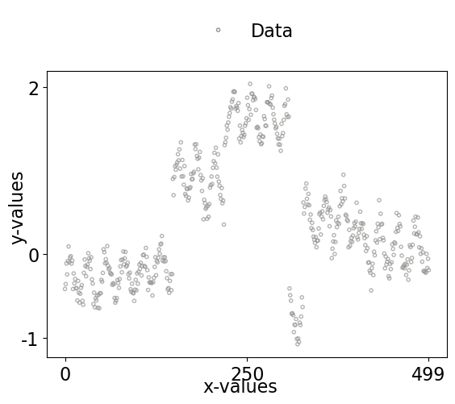

```python
sampler.plot_data()
```

```python
# chatGPT

def rmse(y_true, y_fit): #Root mean squared error
    return np.sqrt(np.mean((y_fit - y_true) ** 2))
```

```python
Bstep = [7,70,700]
Nsamples = [100,1000,10000]
# Anoise already defined

runtime_array = np.zeros((len(Bstep), len(Nsamples), len(Anoise)))
rmse_array = np.zeros((len(Bstep), len(Nsamples), len(Anoise)))

# Now do our grid for loop
for i, b in enumerate(Bstep):
    for j, N in enumerate(Nsamples):
        for k, A in enumerate(Anoise):
            print("B:", b, ", N:", N, "A:", A)

            sampler = bnp.BNPStep(B_max = b)
            sampler.load_data(saveroot + '_' +str(randomseed)+ '_noise_' +str(A)+ '.csv', has_timepoints=True)

            # Start analysis and time
            start = time.time()  # Start timer
            sampler.analyze(num_samples = N)
            end = time.time()  # End timer
            print(f"bnp_step sampled in {end - start:.6f} seconds")
            runtime_array[i,j,k] = end-start

            # Save results
            sampler.results_to_file(outfile=saveroot + '_' +str(randomseed)+ '_noise_' +str(A)+ '_Ns_' +str(N)+ '_bm_' +str(b))
#             sampler.load_data(saveroot + '_' +str(randomseed)+ '_noise_' +str(A)+ '_Ns_' +str(N)+ '_bm_' +str(b)+ '.pkl')

            # compare with ground truth
            df = pd.read_csv(saveroot + '_' +str(randomseed)+ '_noise_' +str(Avalue)+ '.csv', header=None)  # Or use delimiter=',' if needed
            # Get the third column (where I have saved ground truths from above) by index (0-based)
            ground_truth = df.iloc[:, 2]

            step_data = sampler.export_step_data()
            rmse_array[i,j,k] = rmse(ground_truth, step_data)
```

```
B: 7 , N: 100 A: 0.01
bnp_step sampled in 0.080040 seconds
B: 7 , N: 100 A: 0.05
bnp_step sampled in 0.041017 seconds
B: 7 , N: 100 A: 0.2
bnp_step sampled in 0.046862 seconds
B: 7 , N: 1000 A: 0.01
```

```
bnp_step sampled in 0.571328 seconds
B: 7 , N: 1000 A: 0.05
```

```
bnp_step sampled in 0.497090 seconds
B: 7 , N: 1000 A: 0.2
```

```
bnp_step sampled in 0.511006 seconds
B: 7 , N: 10000 A: 0.01
```

```
bnp_step sampled in 6.638556 seconds
B: 7 , N: 10000 A: 0.05
```

```
bnp_step sampled in 7.260280 seconds
B: 7 , N: 10000 A: 0.2
```

```
bnp_step sampled in 5.578530 seconds
B: 70 , N: 100 A: 0.01
```

```
bnp_step sampled in 0.918685 seconds
B: 70 , N: 100 A: 0.05
```

```
bnp_step sampled in 0.862024 seconds
B: 70 , N: 100 A: 0.2
```

```
bnp_step sampled in 0.951335 seconds
B: 70 , N: 1000 A: 0.01
```

```
bnp_step sampled in 9.105251 seconds
B: 70 , N: 1000 A: 0.05
```

```
bnp_step sampled in 9.054153 seconds
B: 70 , N: 1000 A: 0.2
```

```
bnp_step sampled in 9.005909 seconds
B: 70 , N: 10000 A: 0.01
```

```
bnp_step sampled in 106.788414 seconds
B: 70 , N: 10000 A: 0.05
```

```
bnp_step sampled in 2870.983351 seconds
B: 70 , N: 10000 A: 0.2
```

```
bnp_step sampled in 93.327888 seconds
B: 700 , N: 100 A: 0.01
```

```
bnp_step sampled in 51.032303 seconds
B: 700 , N: 100 A: 0.05
```

```
bnp_step sampled in 50.103606 seconds
B: 700 , N: 100 A: 0.2
```

```
bnp_step sampled in 49.047416 seconds
B: 700 , N: 1000 A: 0.01
```

```
bnp_step sampled in 521.738756 seconds
B: 700 , N: 1000 A: 0.05
```

```
bnp_step sampled in 541.318911 seconds
B: 700 , N: 1000 A: 0.2
```

```
bnp_step sampled in 517.542192 seconds
B: 700 , N: 10000 A: 0.01
```

[output not shown]

```python
print('RMSE')
print(rmse_array[:,:,0])
print('')
print(rmse_array[:,:,1])
print('')
print(rmse_array[:,:,2])

print('')
print('Eval Time')
print(runtime_array[:,:,0])
print('')
print(runtime_array[:,:,1])
print('')
print(runtime_array[:,:,2])
```

```
RMSE
[[0.34319805 0.21909398 0.05076698]
 [0.32650473 0.13308559 0.03154716]
 [0.2604061  0.060684   0.        ]]

[[0.57337577 0.21499519 0.02836366]
 [0.34873861 0.15734359 0.02916378]
 [0.24717118 0.05249259 0.        ]]

[[0.32390134 0.29881998 0.2128871 ]
 [0.31065998 0.07090586 0.07017795]
 [0.2316476  0.07092753 0.        ]]

Eval Time
[[8.00399780e-02 5.71328163e-01 6.63855624e+00]
 [9.18684959e-01 9.10525107e+00 1.06788414e+02]
 [5.10323031e+01 5.21738756e+02 0.00000000e+00]]

[[4.10170555e-02 4.97089863e-01 7.26028013e+00]
 [8.62024069e-01 9.05415320e+00 2.87098335e+03]
 [5.01036060e+01 5.41318911e+02 0.00000000e+00]]

[[4.68616486e-02 5.11006117e-01 5.57853007e+00]
 [9.51335192e-01 9.00590897e+00 9.33278880e+01]
 [4.90474157e+01 5.17542192e+02 0.00000000e+00]]
```

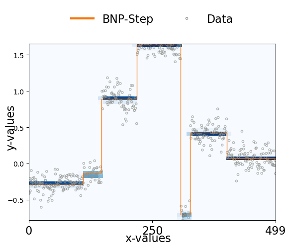

```python
b = 70
N = 10000
A = 0.05
sampler2 = bnp.BNPStep(B_max=b)
sampler2.load_data(saveroot + '_' +str(randomseed)+ '_noise_' +str(A)+ '.csv', has_timepoints=True)
sampler2.results_from_file(saveroot + '_' +str(randomseed)+ '_noise_' +str(A)+ '_Ns_' +str(N)+ '_bm_' +str(b))
sampler2.visualize_results(plot_type='step')
# plt.savefig(saveroot + '_' +str(randomseed)+ '_noise_' +str(A)+ '_Ns_' +str(N)+ '_bm_' +str(b)+'.png')
```

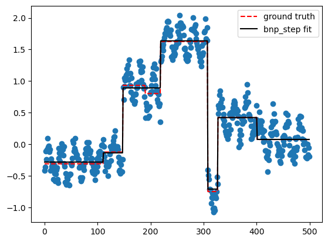

```python
step_data = sampler2.export_step_data()
df = pd.read_csv(saveroot + '_' +str(randomseed)+ '_noise_' +str(Avalue)+ '.csv', header=None)  # Or use delimiter=',' if needed
ground_truth = df.iloc[:, 2]
data = df.iloc[:,1]
times = df.iloc[:,0]

plt.scatter(times, data)
plt.plot(times, ground_truth, 'r--',label='ground truth')
plt.plot(times, step_data, 'k-', label='bnp_step fit')
plt.legend()
```

## Conclusion

As expected:

- More step parameter space to play with is better
- More sampling is better
- Note that having extra time or states doesn't drastically change the result. That is important.

Overall, I think we should aim for ~10000 samples and some high amount of b_max. At least by a factor of 2. We could probably incorporate that based on time and average stepping rate. i.e. $\text{max}(2.5 \times t \times k, 70)$